# Customer Churn Analyst

# Exploratory Data Analysis (EDA)

### **KPIs to Calculate**

- **Monthly Recurring Revenue (MRR)** = sum(MonthlyCharges) for active subscribers
- **Average Order Value (AOV)** = TotalCharges.mean()
- **Churn Rate** = (Churned Customers / Total Customers) * 100
- **Customer Lifetime Value (LTV)** = AOV × Average Tenure
- **Gross Merchandise Value (GMV)** = sum(TotalCharges)

```python
data = df
# Convert 'TotalCharges' to numeric (if needed)
data["TotalCharges"] = pd.to_numeric(data["TotalCharges"], errors="coerce")

# Compute KPIs
total_subscribers = len(data)  # Total number of customers
churned_customers = data[data["Churn"] == "1"].shape[0]
active_customers = total_subscribers - churned_customers

mrr = data["MonthlyCharges"].sum()  # Monthly Recurring Revenue
aov = data["TotalCharges"].mean()   # Average Order Value
churn_rate = (churned_customers / total_subscribers) * 100  # Churn Rate
avg_tenure = data["tenure"].mean()  # Average Customer Tenure
ltv = aov * avg_tenure  # Customer Lifetime Value
gmv = data["TotalCharges"].sum()  # Gross Merchandise Value

# Display Results
print(f"Total Subscribers: {total_subscribers}")
print(f"Churn Rate: {churn_rate:.2f}%")
print(f"Monthly Recurring Revenue (MRR): ${mrr:.2f}")
print(f"Average Order Value (AOV): ${aov:.2f}")
print(f"Customer Lifetime Value (LTV): ${ltv:.2f}")
print(f"Gross Merchandise Value (GMV): ${gmv:.2f}")
```

[output not shown]

### Key Takeaways

1. Improve **customer retention** to reduce churn.
2. Optimize **pricing & upsell strategies** to boost AOV & LTV.
3. Introduce **loyalty programs or long-term plans** to enhance revenue stability.

Next steps: Conduct **churn analysis** and refine **subscription models**.

## Data Overview

```python
# Check descriptive statistics
df.describe().T
```

|  | count | mean | std | min | 25% | 50% | 75% | max |
| --- | --- | --- | --- | --- | --- | --- | --- | --- |
| SeniorCitizen | 7043.0 | 0.162147 | 0.368612 | 0.00 | 0.0 | 0.00 | 0.00 | 1.00 |
| tenure | 7043.0 | 32.371149 | 24.559481 | 0.00 | 9.0 | 29.00 | 55.00 | 72.00 |
| MonthlyCharges | 7043.0 | 64.761692 | 30.090047 | 18.25 | 35.5 | 70.35 | 89.85 | 118.75 |

- SeniorCitizen must be categorical data because 25-50-70 % is 0.00 and min-max equals to 0.00 until 1.00
- Average customer stayed in company is 32 month and 75% customer has a tenure unless 55 month
- The average monthly charge is USD 64.76, while 25% of customers pay more than USD 89.85 per month.

```python
df.info()
```

```
<class 'pandas.core.frame.DataFrame'>
Index: 7043 entries, 7590-VHVEG to 3186-AJIEK
Data columns (total 20 columns):
 #   Column            Non-Null Count  Dtype
---  ------            --------------  -----
 0   gender            7043 non-null   object
 1   SeniorCitizen     7043 non-null   int64
 2   Partner           7043 non-null   object
 3   Dependents        7043 non-null   object
 4   tenure            7043 non-null   int64
 5   PhoneService      7043 non-null   object
 6   MultipleLines     7043 non-null   object
 7   InternetService   7043 non-null   object
 8   OnlineSecurity    7043 non-null   object
 9   OnlineBackup      7043 non-null   object
 10  DeviceProtection  7043 non-null   object
 11  TechSupport       7043 non-null   object
 12  StreamingTV       7043 non-null   object
 13  StreamingMovies   7043 non-null   object
 14  Contract          7043 non-null   object
 15  PaperlessBilling  7043 non-null   object
 16  PaymentMethod     7043 non-null   object
 17  MonthlyCharges    7043 non-null   float64
 18  TotalCharges      7043 non-null   object
 19  Churn             7043 non-null   object
dtypes: float64(1), int64(2), object(17)
memory usage: 1.1+ MB
```

- TotalCharges it must be float not has data type object so i will change it

```python
# Change TotalCharges to float
df["TotalCharges"] = pd.to_numeric(df["TotalCharges"], errors="coerce")
```

## Payment Method Check

```python
df["PaymentMethod"].unique()
```

```
array(['Electronic check', 'Mailed check', 'Bank transfer (automatic)',
       'Credit card (automatic)'], dtype=object)
```

```python
# Delete "automatic" from PaymentMethod
df["PaymentMethod"] = df["PaymentMethod"].str.replace(" (automatic)", "", regex=False)
```

## Missing Values

```python
features_na = [feature for feature in df.columns if df[feature].isnull().sum() > 1]

for feature in features_na:
    print(f"{feature}, {round(df[feature].isnull().mean(), 4)} % Missing values")
```

```
TotalCharges, 0.0016 % Missing values
```

```python
# Check observation of missing values
df[df[features_na[0]].isnull()]
```

| customerID | gender | SeniorCitizen | Partner | Dependents | tenure | PhoneService | MultipleLines | InternetService | OnlineSecurity | OnlineBackup | DeviceProtection | TechSupport | StreamingTV | StreamingMovies | Contract | PaperlessBilling | PaymentMethod | MonthlyCharges | TotalCharges | Churn |
| --- | --- | --- | --- | --- | --- | --- | --- | --- | --- | --- | --- | --- | --- | --- | --- | --- | --- | --- | --- | --- |
| 4472-LVYGI | Female | 0 | Yes | Yes | 0 | No | No phone service | DSL | Yes | No | Yes | Yes | Yes | No | Two year | Yes | Bank transfer | 52.55 | NaN | No |
| 3115-CZMZD | Male | 0 | No | Yes | 0 | Yes | No | No | No internet service | No internet service | No internet service | No internet service | No internet service | No internet service | Two year | No | Mailed check | 20.25 | NaN | No |
| 5709-LVOEQ | Female | 0 | Yes | Yes | 0 | Yes | No | DSL | Yes | Yes | Yes | No | Yes | Yes | Two year | No | Mailed check | 80.85 | NaN | No |
| 4367-NUYAO | Male | 0 | Yes | Yes | 0 | Yes | Yes | No | No internet service | No internet service | No internet service | No internet service | No internet service | No internet service | Two year | No | Mailed check | 25.75 | NaN | No |
| 1371-DWPAZ | Female | 0 | Yes | Yes | 0 | No | No phone service | DSL | Yes | Yes | Yes | Yes | Yes | No | Two year | No | Credit card | 56.05 | NaN | No |
| 7644-OMVMY | Male | 0 | Yes | Yes | 0 | Yes | No | No | No internet service | No internet service | No internet service | No internet service | No internet service | No internet service | Two year | No | Mailed check | 19.85 | NaN | No |
| 3213-VVOLG | Male | 0 | Yes | Yes | 0 | Yes | Yes | No | No internet service | No internet service | No internet service | No internet service | No internet service | No internet service | Two year | No | Mailed check | 25.35 | NaN | No |
| 2520-SGTTA | Female | 0 | Yes | Yes | 0 | Yes | No | No | No internet service | No internet service | No internet service | No internet service | No internet service | No internet service | Two year | No | Mailed check | 20.00 | NaN | No |
| 2923-ARZLG | Male | 0 | Yes | Yes | 0 | Yes | No | No | No internet service | No internet service | No internet service | No internet service | No internet service | No internet service | One year | Yes | Mailed check | 19.70 | NaN | No |
| 4075-WKNIU | Female | 0 | Yes | Yes | 0 | Yes | Yes | DSL | No | Yes | Yes | Yes | Yes | No | Two year | No | Mailed check | 73.35 | NaN | No |
| 2775-SEFEE | Male | 0 | No | Yes | 0 | Yes | Yes | DSL | Yes | Yes | No | Yes | No | No | Two year | Yes | Bank transfer | 61.90 | NaN | No |

```python
# Drop missing values
df.dropna(inplace=True)
```

## Target Values Visualization

```python
plt.style.use("ggplot")
```

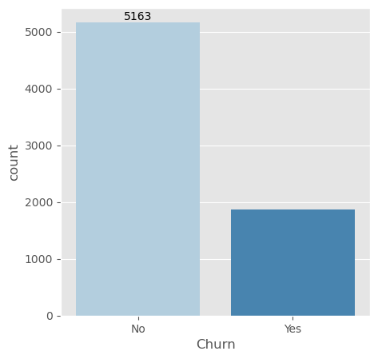

```python
plt.figure(figsize=(5,5))
ax = sns.countplot(x=df["Churn"], hue=df["Churn"], palette="Blues", legend=False)
ax.bar_label(ax.containers[0])
plt.show()
```

Target data class is show imbalance data between churners and not-churners

## Analysis service each customer according to target (churn and no churn)

```python
def plot_categorical_to_target(df,categorical_values, target):
    number_of_columns = 2
    number_of_rows = math.ceil(len(categorical_values)/2)

    fig = plt.figure(figsize = (12, 5*number_of_rows))

    for index, column in enumerate(categorical_values, 1):
        ax = fig.add_subplot(number_of_rows,number_of_columns,index)
        ax = sns.countplot(x = column, data = df, hue = target, palette="Blues")
        ax.set_title(column)
    return plt.show()
```

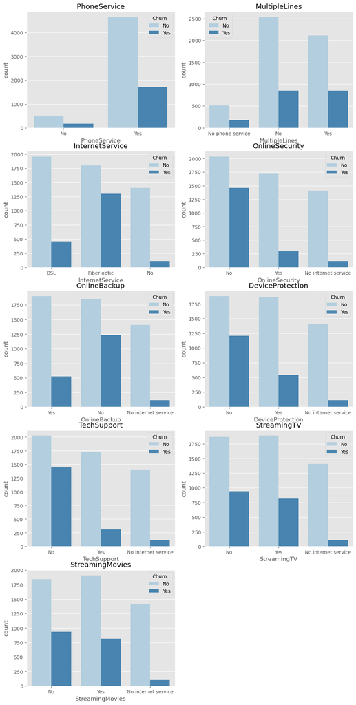

```python
customer_services = ["PhoneService","MultipleLines","InternetService","OnlineSecurity","OnlineBackup",
                    "DeviceProtection","TechSupport","StreamingTV","StreamingMovies"]
plot_categorical_to_target(df,customer_services, "Churn")
```

### **Recommendations**

- **Internet Service**  
  Investigate customer dissatisfaction with Fiber Optic and improve service quality or pricing to reduce churn.
- **Security & Support Services**  
  Promote bundled services with online security, backup, and tech support to retain customers.
- **Streaming Services**  
  Improve the streaming experience by offering better service reliability and customer support to prevent churn.
- **Phone Services**  
  Assess whether phone service users have specific grievances leading to cancellations and offer retention incentives.

## Analysis Customer Account Information - Categorical Values

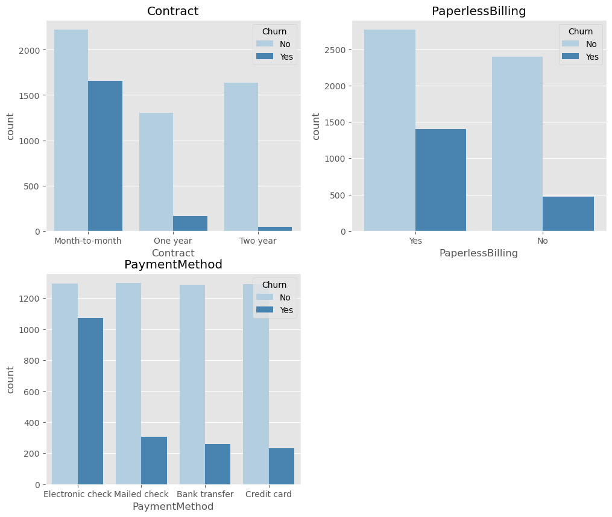

```python
customer_account_cat = ["Contract","PaperlessBilling","PaymentMethod"]
plot_categorical_to_target(df,customer_account_cat,"Churn")
```

Online Services & Protection - Customers without online security, online backup, and tech support tend to churn at higher rates. This indicates that additional services may play a role in customer retention, as users who invest in these services are less likely to leave.

### **Recommendations**

Encourage long-term contracts with promotional campaign to reduce churn. Investigate reasons why paperless billing correlates with higher churn and improve digital payment engagement. Offer loyalty benefits or discounts for customers using electronic checks to improve retention. Promote bundled service packages (e.g., including security and tech support) to enhance customer satisfaction and reduce churn.

## Analysis Customer Account Information

```python
def histogram_plots(df, numerical_values, target):
    number_of_columns = 2
    number_of_rows = math.ceil(len(numerical_values)/2)

    fig = plt.figure(figsize=(12,5*number_of_rows))

    for index, column in enumerate(numerical_values,1):
        ax = fig.add_subplot(number_of_rows, number_of_columns, index)
        ax = sns.kdeplot(df[column][df[target]=="Yes"] ,fill = True)
        ax = sns.kdeplot(df[column][df[target]=="No"], fill = True)
        ax.set_title(column)
        ax.legend(["Churn","No Churn"], loc='upper right')
    return plt.show()
```

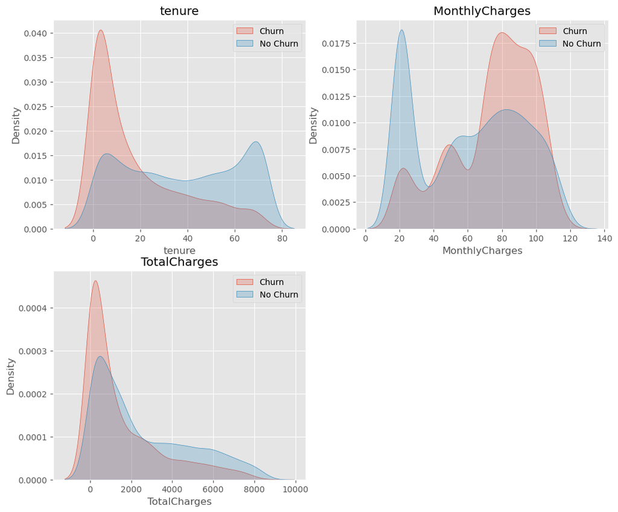

```python
customer_account_num = ["tenure", "MonthlyCharges","TotalCharges"]
histogram_plots(df,customer_account_num, "Churn")
```

## Analysis Customer Demographic Info

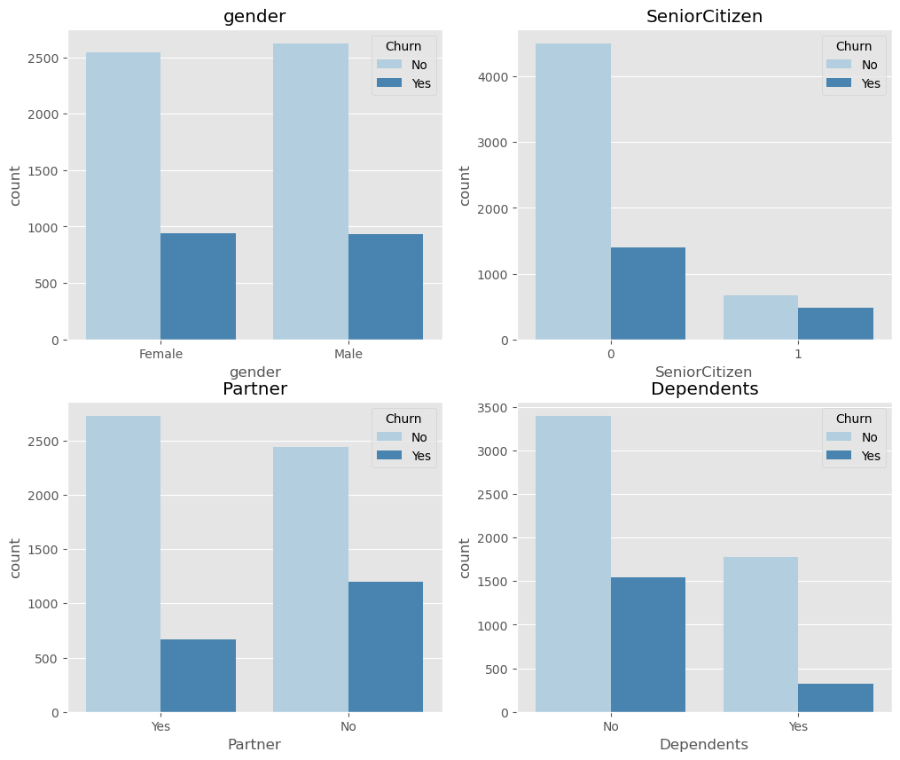

```python
customer_demo_info = ["gender","SeniorCitizen","Partner","Dependents"]
plot_categorical_to_target(df, customer_demo_info,"Churn")
```

## Check Outliers Using Boxplot

```python
def outlier_check_boxplot(df,numerical_values):
    number_of_columns = 2
    number_of_rows = math.ceil(len(numerical_values)/2)

    fig = plt.figure(figsize=(12,5*number_of_rows))
    for index, column in enumerate(numerical_values, 1):
        ax = fig.add_subplot(number_of_rows, number_of_columns, index)
        ax = sns.boxplot(x = column, data = df, palette = "Blues", legend=False)
        ax.set_title(column)
    return plt.show()
```

```python
#numerical_values = ["tenure","MonthlyCharges","TotalCharges"]
#outlier_check_boxplot(df,numerical_values)
```

# Feature Engineering

## Label Encoding

for feature have 2 values

```python
feature_le = ["Partner","Dependents","PhoneService", "Churn","PaperlessBilling"]
def label_encoding(df,features):
    for i in features:
        df[i] = df[i].map({"Yes":1, "No":0})
    return df

df = label_encoding(df,feature_le)
df["gender"] = df["gender"].map({"Female":1, "Male":0})
```

## One Hot Encoding

```python
#features_ohe = ["MultipleLines","InternetService","OnlineSecurity","OnlineBackup",
               # "DeviceProtection","TechSupport","StreamingTV","StreamingMovies","Contract","PaymentMethod"]
#df_ohe = pd.get_dummies(df, columns=features_ohe)
```

# Feature Rescaling : Min-Max Scaling

```python
features_mms = ["tenure","MonthlyCharges","TotalCharges"]

df_mms = pd.DataFrame(df_ohe, columns=features_mms)
df_remaining = df_ohe.drop(columns=features_mms)

mms = MinMaxScaler(feature_range=(0,1))
rescaled_feature = mms.fit_transform(df_mms)

rescaled_feature_df = pd.DataFrame(rescaled_feature, columns=features_mms, index=df_remaining.index)
df = pd.concat([rescaled_feature_df,df_remaining],axis=1)
```

## Correlation Analysis

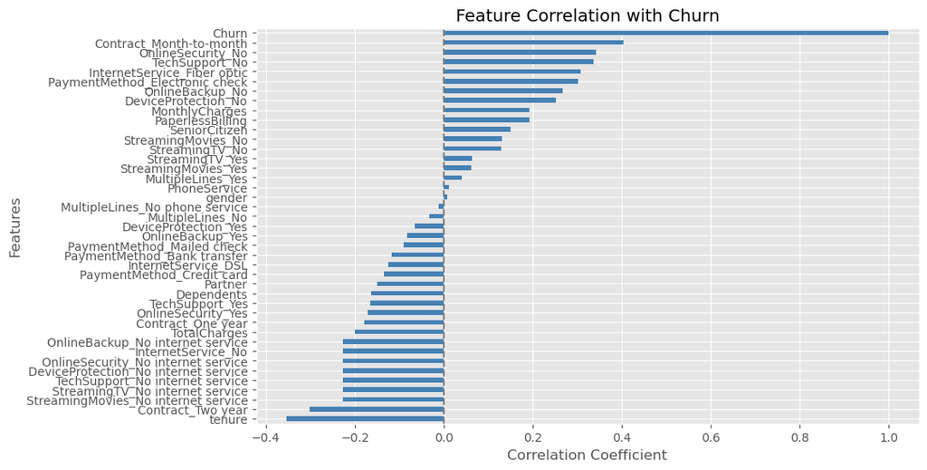

```python
plt.figure(figsize=(10, 6))
df.corr()["Churn"].sort_values().plot(kind="barh", color="steelblue")
plt.axvline(x=0, color="gray", linestyle="--")
plt.title("Feature Correlation with Churn")
plt.xlabel("Correlation Coefficient")
plt.ylabel("Features")
plt.show()
```

# Train Test Split

```python
X = df.drop(columns = "Churn")
y = df.Churn

X_train,X_test, y_train, y_test = train_test_split(X,y,test_size=0.2,random_state=42,stratify=y)
X_train.shape, X_test.shape, y_train.shape, y_test.shape
```

```
((5625, 40), (1407, 40), (5625,), (1407,))
```

# Model Selection And Evaluation Model - KNN, Logistic Regression

```python
from sklearn.metrics import accuracy_score, confusion_matrix, classification_report, roc_curve, roc_auc_score
from sklearn.metrics import precision_recall_curve, auc, f1_score, ConfusionMatrixDisplay, precision_score, recall_score
```

```python
# For logistic Regression
def feature_weights(X_df, classifier, classifier_name):
    weights = pd.Series(classifier.coef_[0], index = X_df.columns.values).sort_values(ascending=False)

    top_10_weights = weights[:10]
    plt.figure(figsize=(7,6))
    plt.title(f"{classifier_name} - Top 10 Features")
    top_10_weights.plot(kind="bar")

    bottom_10_weights = weights[len(weights)-10:]
    plt.figure(figsize=(7,6))
    plt.title(f"{classifier_name} - Bottom 10 Features")
    bottom_10_weights.plot(kind="bar")
    print("")
```

```python
def confusion_matrix_plot(X_train, y_train, X_test, y_test, y_pred, classifier, classifier_name):
    cm = confusion_matrix(y_pred,y_test)
    disp = ConfusionMatrixDisplay(confusion_matrix=cm, display_labels=["No Churn", "Churn"])
    disp.plot()
    plt.title(f"Confusion Matrix - {classifier_name}")
    plt.show()

    print(f"Accuracy Score Test = {accuracy_score(y_pred,y_test)}")
    print(f"Accuracy Score Train = {classifier.score(X_train,y_train)}")
    return print("\n")
```

```python
def roc_curve_auc_score(X_test, y_test, y_pred_probabilities,classifier_name):
    y_pred_prob = y_pred_probabilities[:,1]
    fpr,tpr,thresholds = roc_curve(y_test, y_pred_prob)

    plt.plot([0,1],[0,1],"k--")
    plt.plot(fpr,tpr,label=f"{classifier_name}")
    plt.title(f"{classifier_name} - ROC Curve")
    plt.xlabel("False Positive Rate")
    plt.ylabel("True Positive Rate")
    plt.show()
    return print(f"AUC Score (ROC):{roc_auc_score(y_test,y_pred_prob)}")
```

```python
def precision_recall_curve_and_scores(X_test, y_test, y_pred, y_pred_probabilities, classifier_name):
    y_pred_prob = y_pred_probabilities[:,1]
    precision, recall, thresholds = precision_recall_curve(y_test, y_pred_prob)
    plt.plot(recall,precision, label=f"{classifier_name}")
    plt.title(f"{classifier_name}-ROC Curve")
    plt.xlabel("Recall")
    plt.ylabel("Precision")
    plt.show()
    f1_score_result, auc_score = f1_score(y_test,y_pred), auc(recall,precision)
    return print(f"f1 Score : {f1_score_result} \n AUC Score (PR) : {auc_score}")
```

## K-NN

```python
from sklearn.neighbors import KNeighborsClassifier
knn = KNeighborsClassifier()
knn.fit(X_train, y_train)
y_pred_knn = knn.predict(X_test)
y_pred_knn_proba = knn.predict_proba(X_test)
```

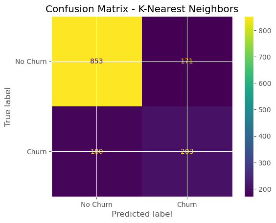

```
Accuracy Score Test = 0.7505330490405118
Accuracy Score Train = 0.8359111111111112
```

```python
confusion_matrix_plot(X_train,y_train,X_test, y_test, y_pred_knn, knn, "K-Nearest Neighbors")
```

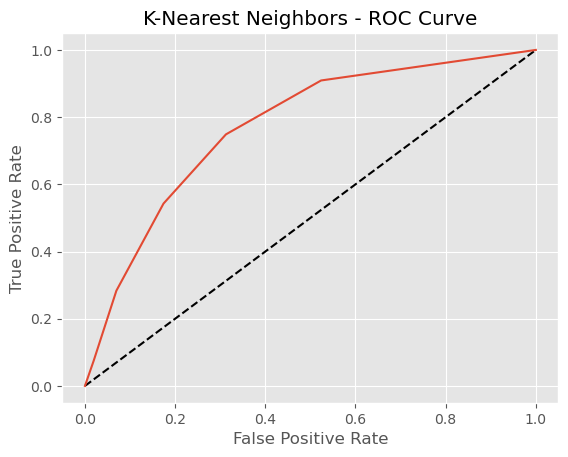

```
AUC Score (ROC):0.7718769898173121
```

```python
roc_curve_auc_score(X_test,y_test,y_pred_knn_proba, "K-Nearest Neighbors")
```

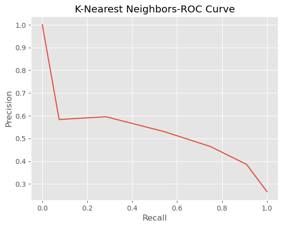

```
f1 Score : 0.5363276089828269
 AUC Score (PR) : 0.5283439083015596
```

```python
precision_recall_curve_and_scores(X_test,y_test,y_pred_knn,y_pred_knn_proba,"K-Nearest Neighbors")
```

## Logistic Regression

```python
from sklearn.linear_model import LogisticRegression
logreg = LogisticRegression(max_iter=1000)
logreg.fit(X_train,y_train)
y_pred_logreg = logreg.predict(X_test)
y_pred_logreg_proba = logreg.predict_proba(X_test)
```

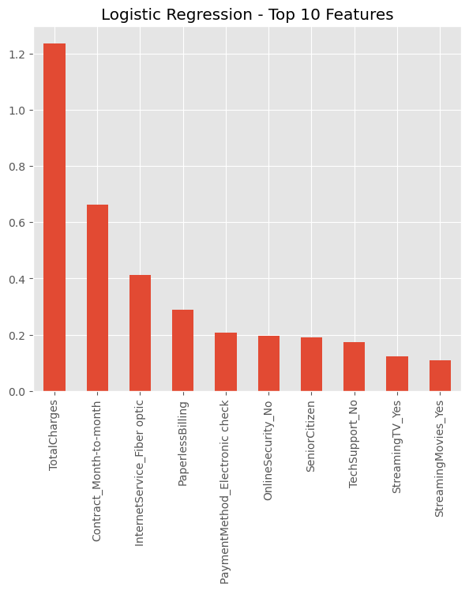

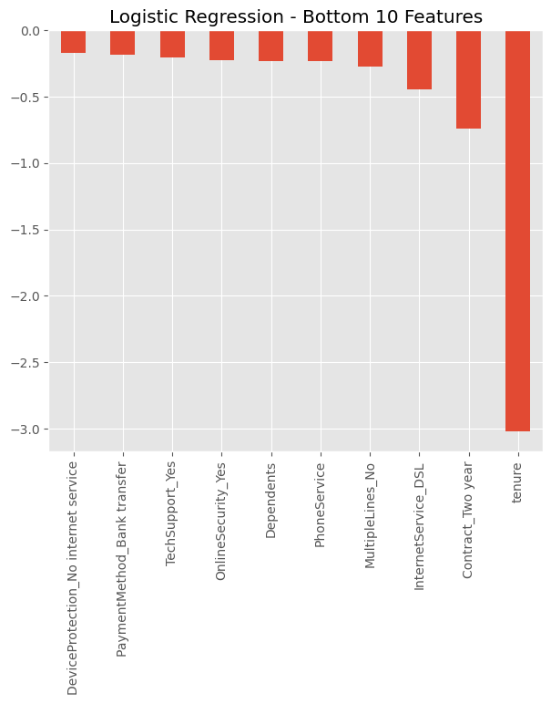

```python
feature_weights(X_train,logreg,"Logistic Regression")
```